# HospitalQuality.Rmd

JLei

4/4/2020

**1 Plot the 30-day mortality rates for heart attack**

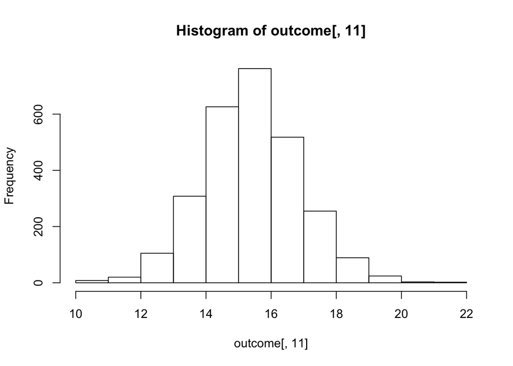

```r
## load the 'outcome-of-care-measures.csv' into a data frame "outcome"
outcome <- read.csv("outcome-of-care-measures.csv", colClasses = "character")

## coerce '30-day death rates from heart attack' to numeric and make a hist
## don't warry about NAs for now
outcome[, 11] <- as.numeric(outcome[, 11])
hist(outcome[, 11])
```

**2 Finding the best hospital in a state**

Below is a function called **best** that take 2 arguments: the 2-char abbr. name of a state and an outcome name. The function reads the **outcome-of-care-measures.csv** file and returns a char vector with the name of the hospital that has the best (ie. lowest) 30-day mortality for the specified outcome (ie. “heart attack”, “heart failure”, or “pneumonia”) in that state.

**Handling ties**. If there is a tie for the best hospital for a given outcome, return the first hospital from the sorted names in an alphabetical order.

```r
best <- function(state, outcome) {
        ## Read outcome data
        f <- read.csv("outcome-of-care-measures.csv", colClasses = "character")
        f[, 11] <- as.numeric(f[, 11])
        f[, 17] <- as.numeric(f[, 17])
        f[, 23] <- as.numeric(f[, 23])

        ## Check that state and outcome are valid
        valid_outcome <- c("heart attack", "heart failure", "pneumonia")
        if (!(outcome %in% valid_outcome)) {
                stop("invalid outcome")
        }
        if (!(state %in% state.abb)) {
                stop("invalid state")
        }

        ## Return hospital name in that state with lowest 30-day death rate

        ## load 'dplyr' packages
        library(dplyr)
        library(tidyr)

        ## subset the outcome data with 5 necessary columns
        f_sub <- f %>%
                select(Hospital.Name,
                       State,
                       HeartAttack = Hospital.30.Day.Death..Mortality..Rates.from.Heart.Attack,
                       HeartFailure = Hospital.30.Day.Death..Mortality..Rates.from.Heart.Failure,
                       Pneumonia = Hospital.30.Day.Death..Mortality..Rates.from.Pneumonia)

        ## further subset by 'state'
        f_sub_state <- f_sub %>% filter(State == state)

        ## return the 1st value of the 'Hospital.Name' after sorting 'outcome' in ascending order and 'Hospital.Name' in alphabetical order
        if (outcome == valid_outcome[1]) {
                f_final <- f_sub_state %>% drop_na(HeartAttack) %>% arrange(HeartAttack, Hospital.Name)
                return(f_final$Hospital.Name[1])
        }
        else if (outcome == valid_outcome[2]) {
                f_final <- f_sub_state %>% drop_na(HeartFailure) %>% arrange(HeartFailure, Hospital.Name)
                return(f_final$Hospital.Name[1])
        }
        else {
                f_final <- f_sub_state %>% drop_na(Pneumonia) %>% arrange(Pneumonia, Hospital.Name)
                return(f_final$Hospital.Name[1])
        }
}


## Test cases below

## expected: "CYPRESS FAIREBANKS MEDICAL CENTER"
best("TX", "heart attack")
```

```
## [1] "CYPRESS FAIRBANKS MEDICAL CENTER"
```

```r
## expected: "FORT DUNCAN MEDICAL CENTER"
best("TX", "heart failure")
```

```
## [1] "FORT DUNCAN MEDICAL CENTER"
```

```r
## expected: "JOHNS HOPKINS HOSPITAL, THE"
best("MD", "heart attack")
```

```
## [1] "JOHNS HOPKINS HOSPITAL, THE"
```

```r
## expected: "GREATER BALTIMORE MEDICAL CENTER"
best("MD", "pneumonia")
```

```
## [1] "GREATER BALTIMORE MEDICAL CENTER"
```

```r
## expected: Error in best("BB", "heart attack") : invalid state
## best("BB", "heart attack")

## expected: Error in best("NY", "hert attack") : invalid outcome
## best("NY", "hert attack")
```

**3 Ranking hospitals by outcome in a state**

Below is a function **rankhospital** that takes 3 arguments: the 2-char abbr. name of a state ( *state*), an outcome ( *outcome*), and the ranking of a hospital in that state for that outcome ( *num*). This function reads the **outcome-of-care-measures.csv** file and returns a char vector with the name of the hospital that has the ranking specified by the *num* argument.

**Handling ties**. If there is a tie among multiple hospitals for a given outcome, rank the hospitals in alphabetical order.

```r
rankhospital <- function(state, outcome, num = "best") {
        ## call 'best' function if no input to 'num' argument
        if (num == "best") {
                best(state, outcome)
        }

        ## Read outcome data
        f <- read.csv("outcome-of-care-measures.csv", colClasses = "character")
        f[, 11] <- as.numeric(f[, 11])
        f[, 17] <- as.numeric(f[, 17])
        f[, 23] <- as.numeric(f[, 23])

        ## Check that state and outcome are valid
        valid_outcome <- c("heart attack", "heart failure", "pneumonia")
        if (!(outcome %in% valid_outcome)) {
                stop("invalid outcome")
        }
        if (!(state %in% state.abb)) {
                stop("invalid state")
        }
        if (!is.numeric(num) & !(num %in% c("best","worst"))) {
                stop("invalid num")
        }

        ## Return hospital name in that state with lowest 30-day death rate

        ## load 'dplyr' packages
        library(dplyr)
        library(tidyr)

        ## subset the outcome data with 5 necessary columns
        f_sub <- f %>%
                select(Hospital.Name,
                       State,
                       HeartAttack = Hospital.30.Day.Death..Mortality..Rates.from.Heart.Attack,
                       HeartFailure = Hospital.30.Day.Death..Mortality..Rates.from.Heart.Failure,
                       Pneumonia = Hospital.30.Day.Death..Mortality..Rates.from.Pneumonia)

        ## further subset by 'state'
        f_sub_state <- f_sub %>% filter(State == state)

        ## return the num_th value of the 'Hospital.Name' after sorting 'outcome' in ascending order and 'Hospital.Name' in alphabetical order
        if (outcome == valid_outcome[1]) {
                f_final <- f_sub_state %>% drop_na(HeartAttack) %>% arrange(HeartAttack, Hospital.Name)
                l <- length(f_final$State)
                ## return the last 'Hospital.Name' for the "worst" ranked
                if (num == "worst") {
                        return(f_final$Hospital.Name[l])
                }
                else if (num > l) {
                        return(NA)
                }
                return(f_final$Hospital.Name[num])
        }

        else if (outcome == valid_outcome[2]) {
                f_final <- f_sub_state %>% drop_na(HeartFailure) %>% arrange(HeartFailure, Hospital.Name)
                l <- length(f_final$State)
                if (num == "worst") {
                        return(f_final$Hospital.Name[l])
                }
                else if (num > l) {
                        return(NA)
                }
                return(f_final$Hospital.Name[num])
        }

        else {
                f_final <- f_sub_state %>% drop_na(Pneumonia) %>% arrange(Pneumonia, Hospital.Name)
                l <- length(f_final$State)
                if (num == "worst") {
                        return(f_final$Hospital.Name[l])
                }
                else if (num > l) {
                        return(NA)
                }
                return(f_final$Hospital.Name[num])
        }
}


## Test cases below

## expected: "DETAR HOSPITAL NAVARRO"
rankhospital("TX", "heart failure", 4)
```

```
## [1] "DETAR HOSPITAL NAVARRO"
```

```r
## expected: "HARFORD MEMORIAL HOSPITAL"
rankhospital("MD", "heart attack", "worst")
```

```
## [1] "HARFORD MEMORIAL HOSPITAL"
```

```r
## expected: NA
rankhospital("MN", "heart attack", 5000)
```

```
## [1] NA
```

**4 Ranking hospitals in all states**

Below is a function called **rankall** that takes 2 arguments: an outcome name ( *outcom*) and a hospital ranking ( *num*). The function reads the **outcome-of-care-measures.csv** file and returns a 2-column data frame containing the hospital in each state that has the ranking specified in *num*. The function should return a value for every state (some may be **NA**). The first column in the data frame is named **hospital**, which contains the hospial name, and the second column is named **state**, which contains the 2-char abbr. for the state name. Hospitals that do not have data on a particular outcome should be excluded from the set of hospitals when deciding the rankings.

**Handling ties**. The **rankall** function should handle ties in the 30-day mortality rate in the same way that the **rankhospital** function handle ties.

```r
rankall <- function(outcome, num = "best"){
        ## make a char vector of 'hospital' by running 'rankhospital' function with all states
        hospital <- character()
        for (i in state.abb) {
                new_hospital <- rankhospital(i, outcome, num)
                hospital <- append(hospital, new_hospital)
        }

        ## make a data frame with 2 columns
        ## col1 is hospitals from above
        ## col2 is states in alphabetical order
        data.frame("hospital" = hospital, state = state.abb)
}


## Test cases below
## head(rankall("heart attack", 20), 10)
## tail(rankall("pneumonia", "worst"), 3)
## tail(rankall("heart failure"), 10)
```